# Population structure

Evgenija Gagaleska

2025-01-01

```r
# Load the required libraries
library(dartR)
library(adegenet)
library(tidyverse)
library(proxy)
library(iterpc)
library(expm)
library(directlabels)
library(MASS)
library(gplots)
library(rrBLUP)
```

# Import the data

Something is wrong with the data, so we need to correct it:

```r
corr_data <- paste("./plink",
                   "--file NordicDogs_4mars2014",                # PLINK binary input files (prefix only)
                   "--export ped",                 # Specify 'ped' as the output format
                   "--allow-extra-chr",
                   "--chr-set 38",
                   "--out NordicDogs_corr")        # Specify output prefix
system(corr_data)
```

```r
dogs<-read.PLINK("NordicDogs.raw", ped.file = "NordicDogs_corr.ped", map.file = "NordicDogs_corr.map")
```

```
##
##  Reading PLINK raw format into a genlight object...
##
##
##  Reading loci information...
##
##  Reading and converting genotypes...
## .
##  Building final object...
##
## ...done.
```

```r
dogs<-gl.compliance.check(dogs)
```

```
## Starting gl.compliance.check
##   Processing genlight object with SNP data
##   The slot loc.all, which stores allele name for each locus, is empty.
## Creating a dummy variable (A/C) to insert in this slot.
##   Checking coding of SNPs
##     SNP data scored NA, 0, 1 or 2 confirmed
##   Checking locus metrics and flags
##   Recalculating locus metrics
##   Checking for monomorphic loci
##     Dataset contains monomorphic loci
##   Checking for loci with all missing data
##     No loci with all missing data detected
##   Checking whether individual names are unique.
##   Checking for individual metrics
##   Warning: Creating a slot for individual metrics
##   Checking for population assignments
##     Population assignments confirmed
##   Spelling of coordinates checked and changed if necessary to
##             lat/lon
## Completed: gl.compliance.check
```

# POPULATION STRUCTURE

## PCA - Principal component analysis

Principal component analysis (PCA) is a statistical procedure that is commonly used in genomics to reduce the dimensionality of large datasets. It reduces the complexity of data sets while preserving the covariance of the data. Covariance is a measure that determines how two random variables are related. The results of PCA are used to design studies, identify and describe individuals and populations, and draw historical and ethnobiological conclusions about origin, evolution, dispersion, and relatedness. It is a powerful tool that can be used to visualize data, identify patterns, and uncover hidden relationships between variables.

Population genomics -> many SNPs for many individuals!

To create a PCA graph, we will use two commands. The first command calculates the PCA and the second command draws the graph. The command used to calculate the PCA in dartR is gl.pcoa(). You need to define the name of the object in which you want to save the PCA calculation data.

If I have a question in the exam, I have to specify how many variants I have depending on how many principal components I choose. For example if I choose 1 and 2, I should count on y-axis and comment this on the axis report.

- E.g. pca.

[figure not shown]

Calculation PCA

[figure not shown]

Calculate principle components:

```r
pca <- gl.pcoa(dogs)
```

```
## Starting gl.pcoa
##   Processing genlight object with SNP data
##   Performing a PCA, individuals as entities, loci as attributes, SNP genotype as state
```

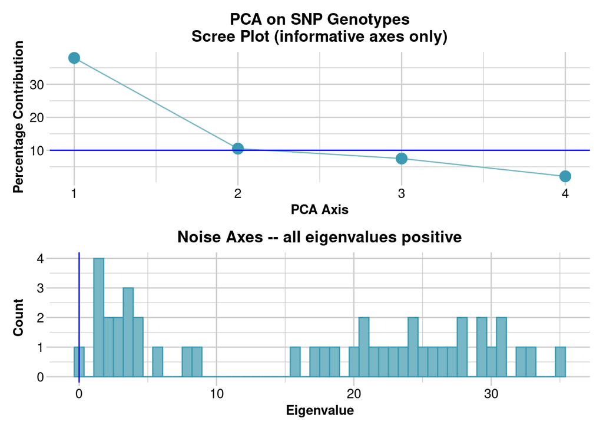

```
## Completed: gl.pcoa
```

[figure not shown]

Plot

Two graphs are drawn, the Scree Plot, which is intended to explain the PCA and decide how many components need to be preserved. So, the first component (value 1 on the PCA Axis) contributes to the explanation of 38% of the variance in our data, the second explains 10%, … To display the data on a 2D graph, always take the 1st and 2nd component, as they contribute to the greatest explanation of variance. To draw the graph, use the following command:

```
## Starting gl.pcoa.plot
##   Processing an ordination file (glPca)
##   Processing genlight object with SNP data
##   Plotting populations in a space defined by the SNPs
##   Preparing plot .... please wait
```

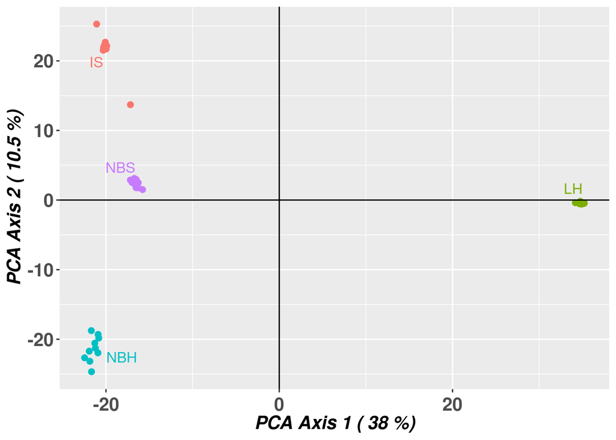

```
## Completed: gl.pcoa.plot
```

```r
gl.pcoa.plot(x = dogs, glPca = pca)
```

The graph visualizes the structure of our data. Each point represents one individual/sample, which is colored based on the population to which it belongs. From the graph, we can see that we have 4 populations (IS, NBS, NBH, and LH). On the X-axis we have the 1st component, which explains 38% of the variance and on the Y-axis the 2nd component, which explains 10.5% of the variance. From the graph, we can see that the LH population differs the most from the other 3 populations. The other 3 populations also differ from each other, but this difference is not so great.

If you want to play a little, you can also draw a 3D graph by adding the variable “zaxis = 3”.

```r
gl.pcoa.plot(x = dogs, glPca = pca, zaxis = 3)
```

```
## Starting gl.pcoa.plot
##   Processing an ordination file (glPca)
##   Processing genlight object with SNP data
##   Displaying a three dimensional plot, mouse over for details for each point
##   May need to zoom out to place 3D plot within bounds
## Completed: gl.pcoa.plot
```

```r
# z-axis = 3 means the third principal component
```

In 3D view, we also have the third component, which explains 7.5% of the variance.

## NEIGHBOUR JOINING TREE

In the 1st set of exercises, you learned about phylogenetic trees. Such trees can also be calculated and drawn to summarize genetic similarities between populations. The command is as follows:

```r
gl.tree.nj(dogs, type = "phylogram")
```

```
## Starting gl.tree.nj
##   Processing genlight object with SNP data
##   Converting to a matrix of frequencies, locus by populations
##   Computing Euclidean distances
```

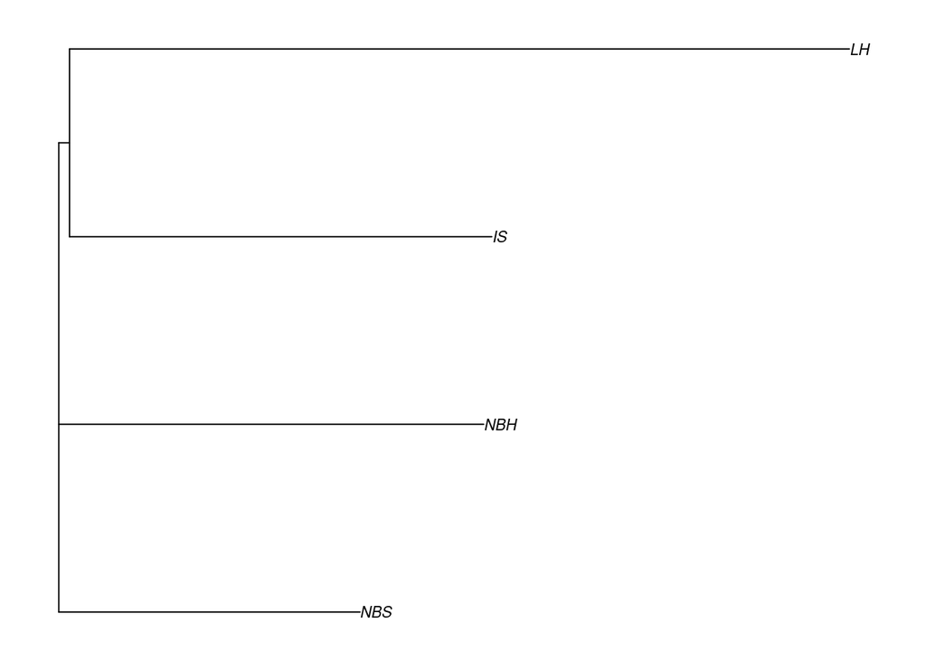

```
## Completed: gl.tree.nj
```

```
##
## Phylogenetic tree with 4 tips and 2 internal nodes.
##
## Tip labels:
##   IS, LH, NBH, NBS
##
## Unrooted; includes branch lengths.
```

The tree is interpreted in a similar way as in phylogeny, although in this case there are only 4 populations.

## STRUCTURE

```r
str <- gl.run.structure(dogs[,1:1000], k.range= 1:6, num.k.rep = 2, exec = "./structure", numreps=200, burnin=100)
```

```
## Starting gl.run.structure
##   Processing genlight object with SNP data
```

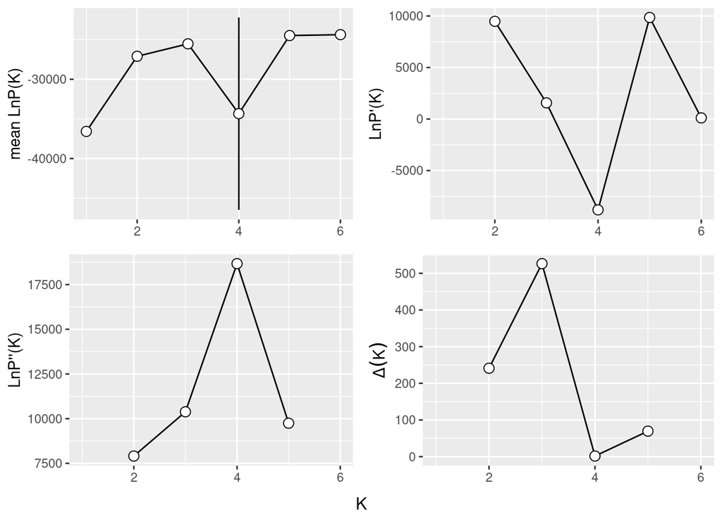

[figure not shown]

```
## Completed: gl.run.structure
```

To draw a graph of population structure, use the command:

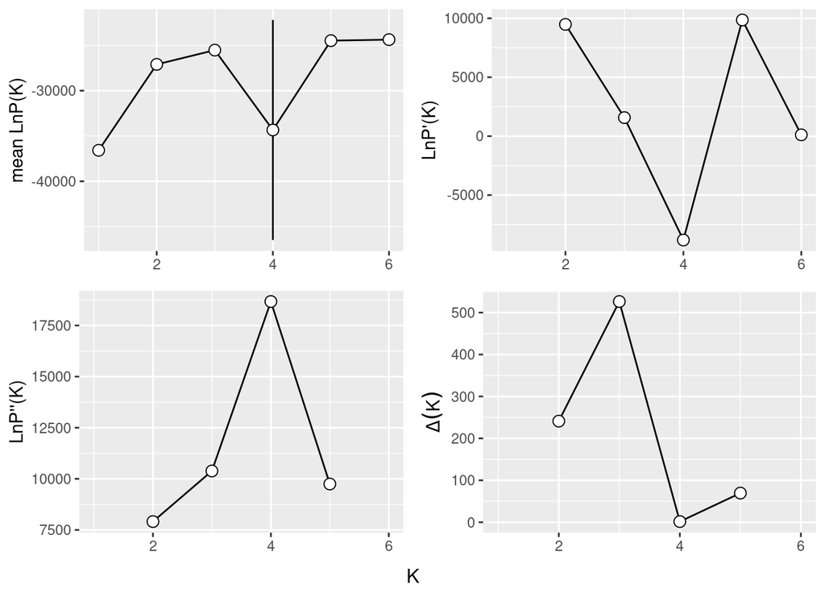

```
## $df
##   k reps mean.ln.k      sd.ln.k    ln.pk   ln.ppk   delta.k
## 1 1    2 -36580.65     4.313351       NA       NA        NA
## 2 2    2 -27098.70    32.809755  9481.95  7910.00 241.08684
## 3 3    2 -25526.75    19.728279  1571.95 10384.35 526.36877
## 4 4    2 -34339.15 12140.245616 -8812.40 18670.85   1.53793
## 5 5    2 -24480.70   140.289985  9858.45  9747.10  69.47823
## 6 6    2 -24369.35    76.155400   111.35       NA        NA
##
## $plots
## $plots$mean.ln.k
```

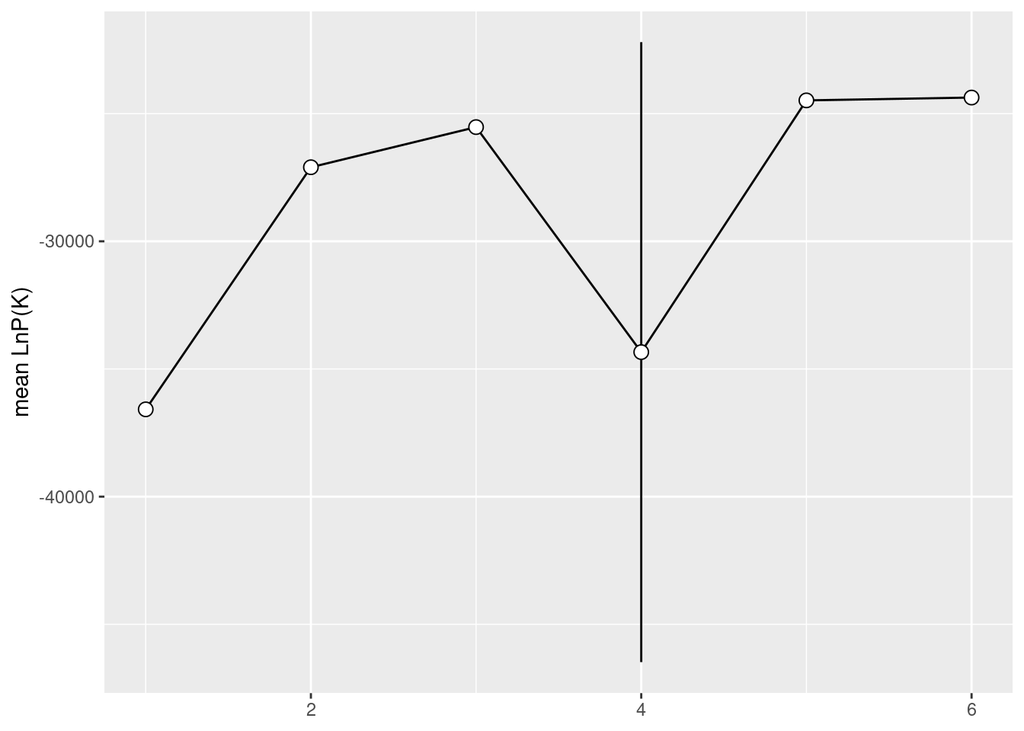

```
##
## $plots$ln.pk
```

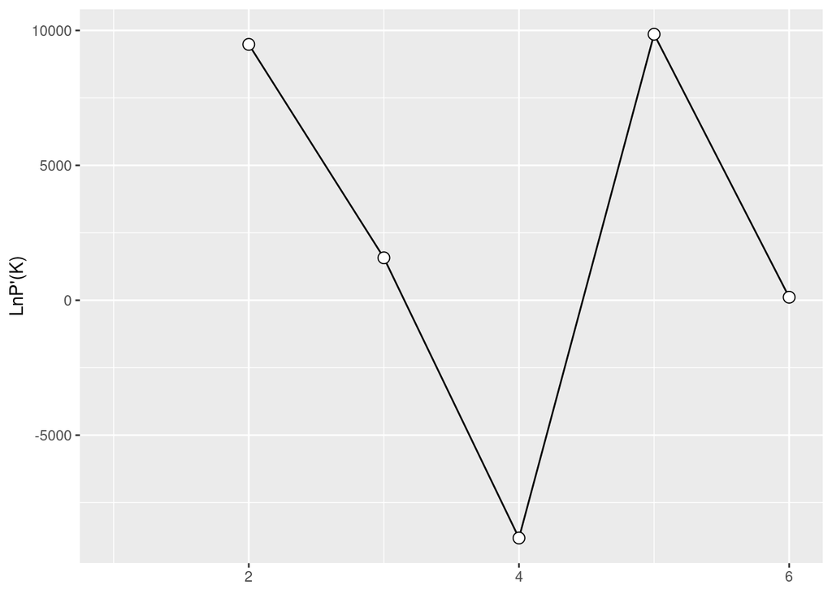

```
##
## $plots$ln.ppk
```

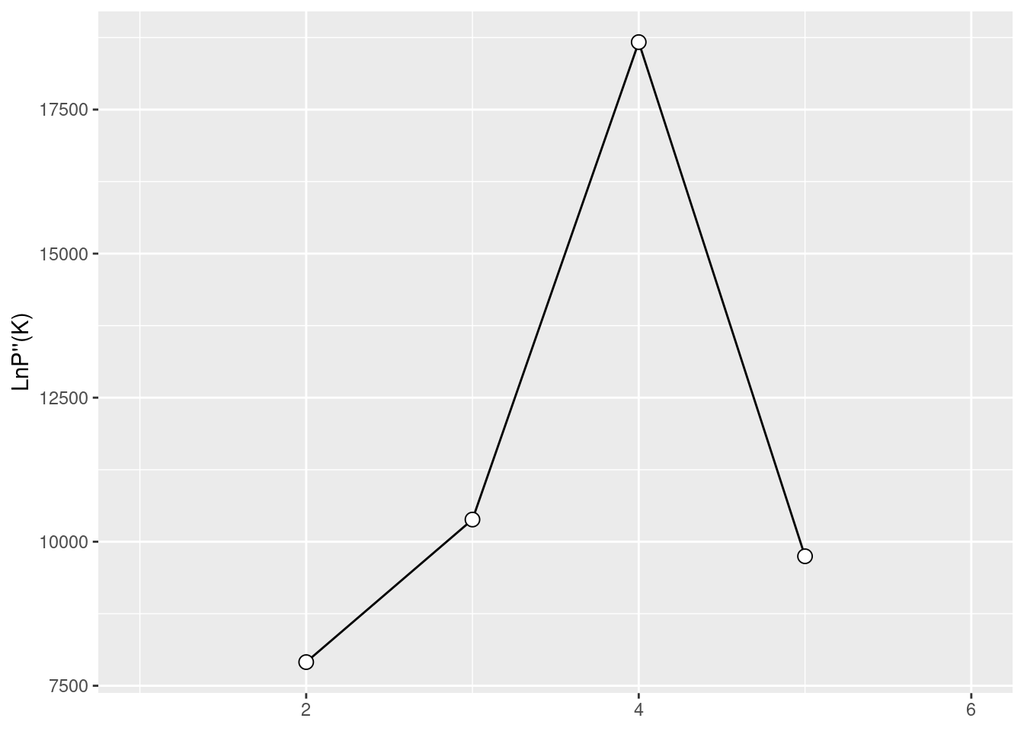

```
##
## $plots$delta.k
```

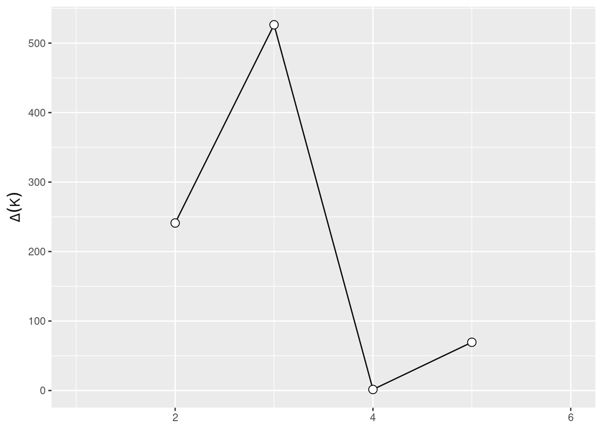

```r
gl.evanno(str)
```

```
## Starting gl.plot.structure
```

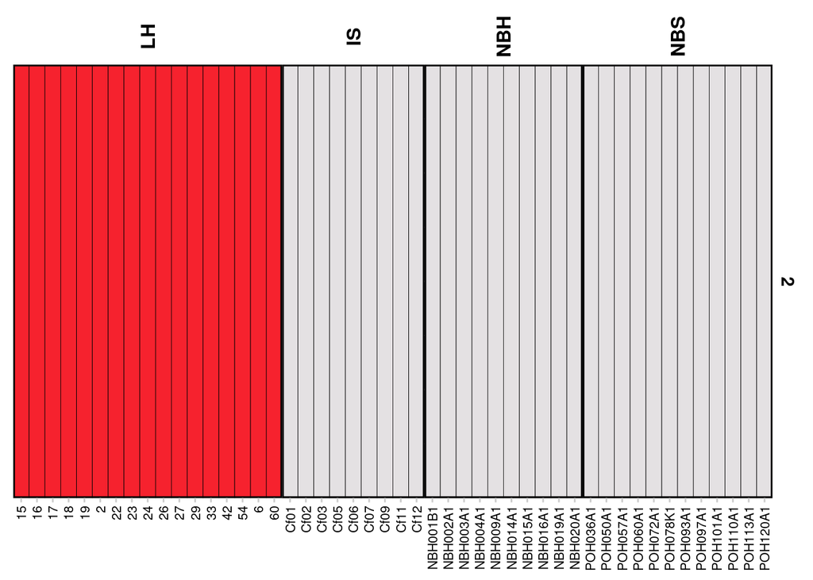

```
## Completed: gl.plot.structure
```

```r
gl.plot.structure(str, K=2)
```

```
## Starting gl.plot.structure
```

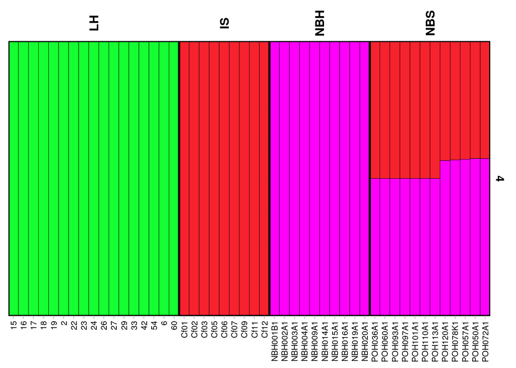

```
## Completed: gl.plot.structure
```

```r
gl.plot.structure(str, K=4)
```

## ISOLATION BY DISTANCE

The correlation of genetic diversity between individuals decreases as a function of geographic distance. It is usually the simplest model of the cause of genetic isolation between populations. Migration is usually localized in space, which is why individuals from nearby subpopulations are expected to be more genetically similar. To calculate IBD, in addition to genetic data, we also need coordinates. The IBD command calculates the FST distance and the Euclidean distance (distance in space between individuals).

Before running the command, we need to import the table with the coordinates. We do this with the read.table command, as the data is stored in a .txt file. We need to save the data in an object. We add the header = T parameter, because in our table the column names are in the first row.

```r
coordinates <- read.table("koordinate.txt",header = T)
as.data.frame(coordinates)
```

```
##       id       lat        lon
## 1   NBH1  59.53669   5.995681
## 2   NBH2  60.32728   5.765645
## 3   NBH3  59.59346   5.173156
## 4   NBH4  60.41849   5.997113
## 5   NBH5  59.88235   5.281552
## 6   NBH6  60.38275   5.914496
## 7   NBH7  60.10441   5.218101
## 8   NBH8  60.44375   5.794042
## 9   NBH9  60.08612   5.698063
## 10 NBH10  59.60227   5.088788
## 11  NBS1  62.84657  32.738255
## 12  NBS2  62.62915  32.999024
## 13  NBS3  62.25887  32.520957
## 14  NBS4  62.83628  32.576176
```

[output cut: 34 more lines]

Now we can run the gl.ibd command, which will calculate isolation with distance.

```r
gl.ibd(dogs, coordinates = coordinates[,2-3], distance = "Fst")
```

```
## Analysis performed on the genlight object.
```

```
## 'nperm' >= set of all permutations: complete enumeration.
```

```
## Set of permutations < 'minperm'. Generating entire set.
```

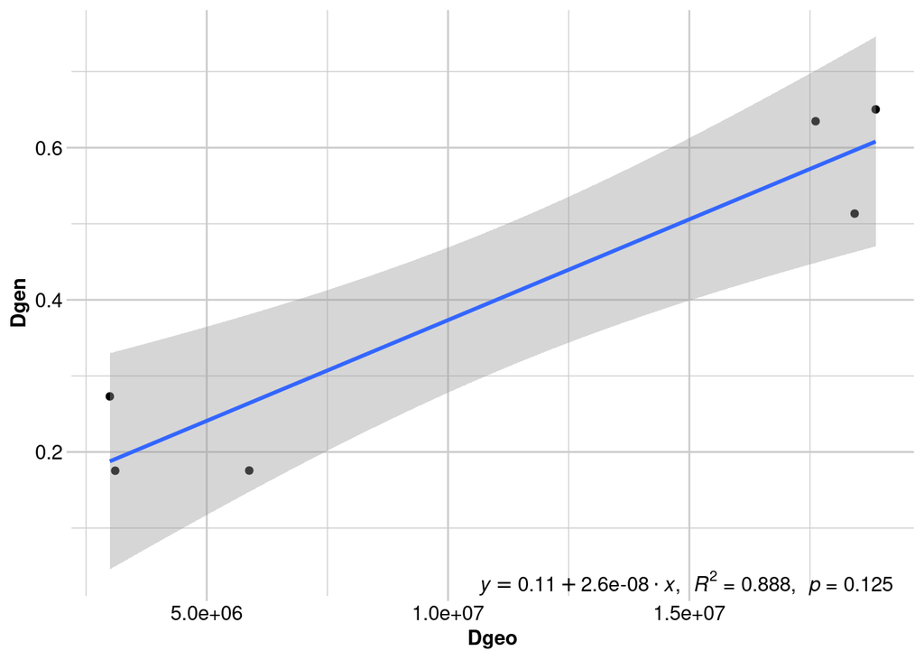

```
##   Coordinates used from: data.frame lat/lon (Mercator transformed)
##   Transformation of Dgeo: Dgeo
##   Genetic distance: Fst
##   Tranformation of Dgen:  Dgen
##
## Mantel statistic based on Pearson's product-moment correlation
##
## Call:
## vegan::mantel(xdis = Dgen, ydis = Dgeo, permutations = permutations,      na.rm = TRUE)
##
## Mantel statistic r: 0.9425
##       Significance: 0.125
##
## Upper quantiles of permutations (null model):
##   90%   95% 97.5%   99%
## 0.940 0.980 0.985 0.985
## Permutation: free
## Number of permutations: 23
##
##
## Completed: gl.ibd
```

```
## $Dgen
##            IS        LH       NBH
## LH  0.6503728
## NBH 0.2730587 0.6347757
## NBS 0.1755985 0.5133535 0.1753915
##
## $Dgeo
##           IS       LH      NBH
## LH  18860453
## NBH  2991798 17616085
## NBS  5880331 18424767  3103178
##
## $mantel
##
## Mantel statistic based on Pearson's product-moment correlation
##
## Call:
## vegan::mantel(xdis = Dgen, ydis = Dgeo, permutations = permutations,      na.rm = TRUE)
##
## Mantel statistic r: 0.9425
##       Significance: 0.125
##
## Upper quantiles of permutations (null model):
##   90%   95% 97.5%   99%
## 0.940 0.980 0.985 0.985
## Permutation: free
## Number of permutations: 23
```

### Density plot

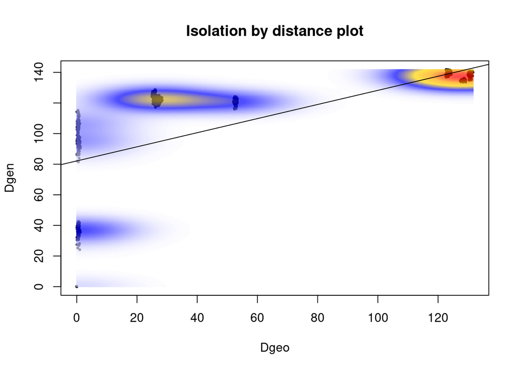

```r
#Prepeare the matrices
Dgeo <- as.matrix(dist(coordinates[,2-3]))
Dgen <- as.matrix(dist(as.matrix(dogs)))

#Calculate density
dens <- kde2d(as.vector(Dgeo), as.vector(Dgen), n=300)

#Create color palette
myPal <- colorRampPalette(c("white", "blue", "gold", "orange", "red"))

#Plot all together
plot(Dgeo, Dgen, pch=20,cex=.5)
image(dens, col=transp(myPal(300),.7), add=TRUE)

# Calculate distance
dist_lm <- lm(as.vector(Dgen) ~ as.vector(Dgeo))
abline(dist_lm)
title("Isolation by distance plot")
```

## Other visualizations

If we want to calculate identity by descent matrix (IBS matrix) we can run this:

```r
#Calculates an identity by descent matrix
gl.grm(dogs)
```

```
## Starting gl.grm
##   Processing genlight object with SNP data
```

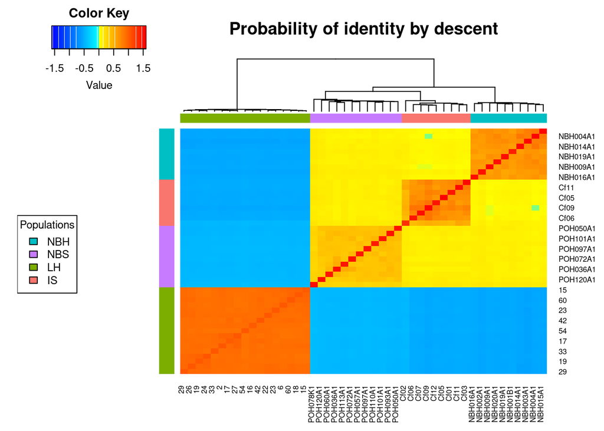

```
## Completed: gl.grm
```

We can also draw a network:

```r
gl.grm.network(x=dogs, G = gl.grm(dogs), method = "kk")
```

```
## Starting gl.grm.network
##   Processing genlight object with SNP data
## Starting gl.grm
##   Processing genlight object with SNP data
```

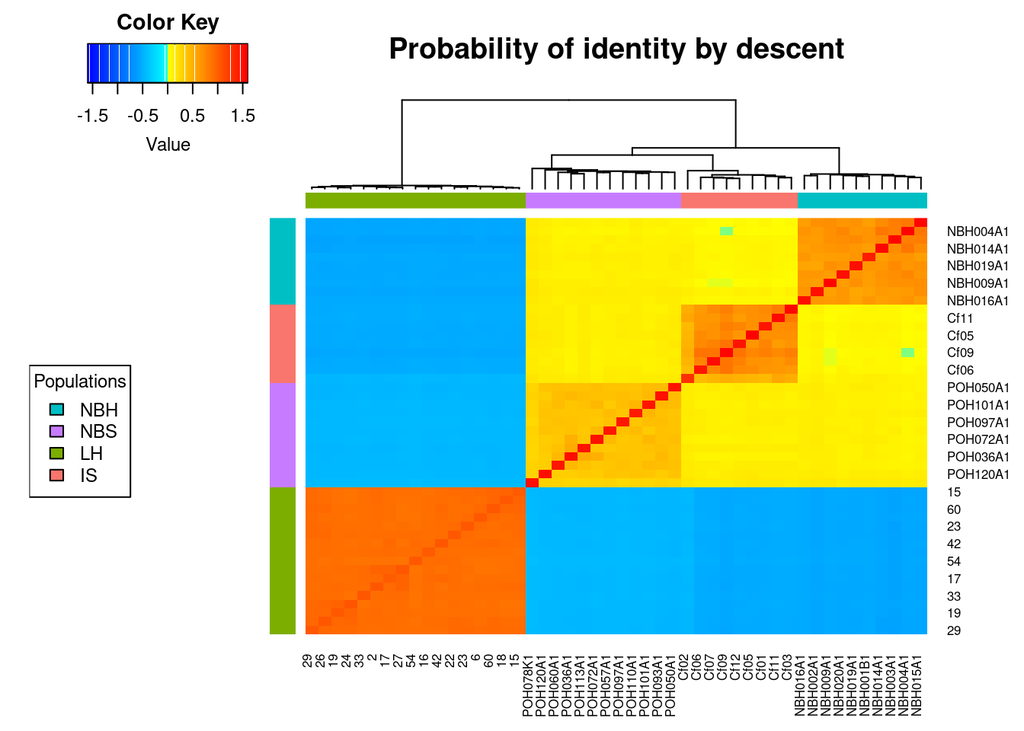

```
## Completed: gl.grm
```

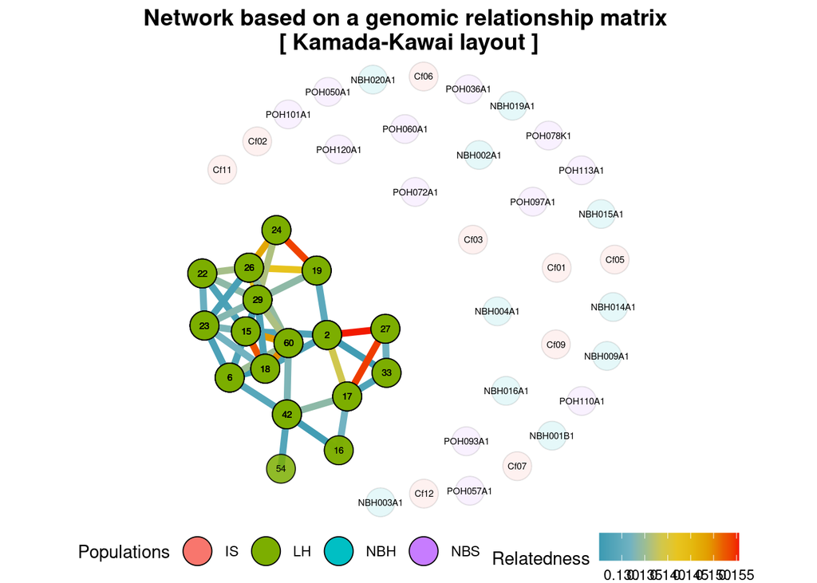

```
## Completed: gl.grm.network
```

```r
#Mapa (if it doesn't work in Viewer, open with Zoom).
#gl.map.interactive(dogs)
```

Calculating alpha and beta diversity:

```r
gl.report.diversity(dogs)
```

[output not shown]

```
##   |                            |==================  |  88% Calculating two_H/D_beta...      |                            |====================| 100% Done.
```

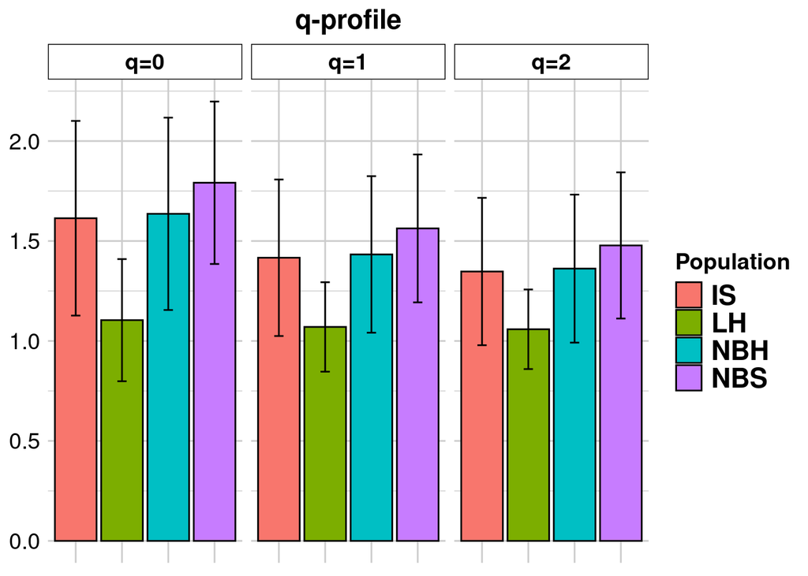

```
##
##
## |    | nloci| m_0Ha| sd_0Ha| m_1Ha| sd_1Ha| m_2Ha| sd_2Ha|
## |:---|-----:|-----:|------:|-----:|------:|-----:|------:|
## |IS  | 19998| 0.614|  0.487| 0.309|  0.279| 0.205|  0.196|
## |LH  | 19983| 0.104|  0.305| 0.052|  0.163| 0.035|  0.111|
## |NBH | 19996| 0.636|  0.481| 0.321|  0.278| 0.213|  0.196|
## |NBS | 19999| 0.791|  0.406| 0.415|  0.258| 0.278|  0.186|
##
##
## pairwise non-missing loci
##
## |    |    IS|    LH|   NBH| NBS|
## |:---|-----:|-----:|-----:|---:|
## |IS  |    NA|    NA|    NA|  NA|
## |LH  | 19981|    NA|    NA|  NA|
## |NBH | 19994| 19979|    NA|  NA|
## |NBS | 19997| 19982| 19996|  NA|
##
##
## 0_H_beta
##
## |    |    IS|    LH|   NBH|   NBS|
## |:---|-----:|-----:|-----:|-----:|
## |IS  |    NA| 0.273| 0.222| 0.213|
## |LH  | 0.308|    NA| 0.269| 0.232|
## |NBH | 0.134| 0.317|    NA| 0.207|
## |NBS | 0.119| 0.353| 0.110|    NA|
##
##
## 1_H_beta
##
## |    |    IS|    LH|   NBH|   NBS|
## |:---|-----:|-----:|-----:|-----:|
## |IS  |    NA| 0.254| 0.251| 0.249|
## |LH  | 0.220|    NA| 0.251| 0.237|
## |NBH | 0.085| 0.214|    NA| 0.237|
## |NBS | 0.039| 0.167| 0.033|    NA|
##
##
```

[output cut: 42 more lines]

```
## |IS  |    NA| 0.321| 0.286| 0.274|
## |LH  | 1.286|    NA| 0.316| 0.284|
## |NBH | 1.124| 1.278|    NA| 0.257|
## |NBS | 1.072| 1.215| 1.063|    NA|
##
##
## 2_D_beta
##
## |    |    IS|    LH|   NBH|   NBS|
## |:---|-----:|-----:|-----:|-----:|
## |IS  |    NA| 0.274| 0.253| 0.233|
## |LH  | 1.275|    NA| 0.272| 0.248|
## |NBH | 1.113| 1.268|    NA| 0.231|
## |NBS | 1.055| 1.217| 1.047|    NA|
## Completed: gl.report.diversity
```